# Biostat 203B Homework 2

Due Feb 5 @ 11:59PM

Lillian Chen

```r
knitr::opts_chunk$set(echo = TRUE, cache = TRUE)
library(tidyverse)
library(data.table)
library(lubridate)
```

#change

```r
os <- sessionInfo()$running
if (str_detect(os, "Linux")) {
  mimic_path <- "/usr/203b-data/mimic-iv"
} else if (str_detect(os, "macOS")) {
  mimic_path <- "/Users/huazhou/Documents/Box Sync/MIMIC/mimic-iv-0.4"
}
```

Use tidyverse (ggplot2, dplyr) to explore the [MIMIC-IV](https://mimic-iv.mit.edu) data introduced in [homework 1](https://ucla-biostat203b-2021winter.github.io/hw/hw1/hw1.html).

```r
system(str_c("tree -s -L 2 ", shQuote(mimic_path)), intern = TRUE)
```

```
## [1] "Too many parameters - -L"
```

## Q1. PhysioNet credential

At this moment, you should already get credentialed on the PhysioNet. Please include a screenshot of your `Data Use Agreement for the MIMIC-IV (v0.4)`.

**Solution**:

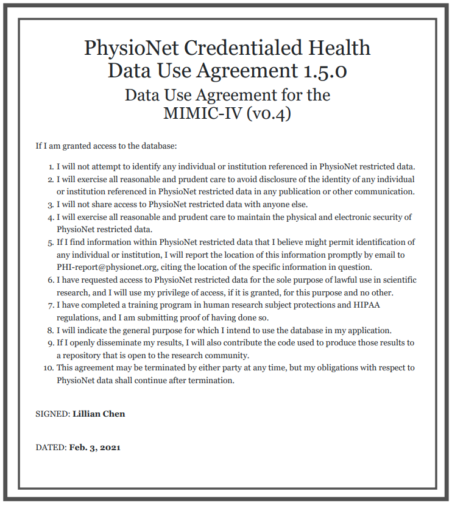

## Q2. `read.csv` (base R) vs `read_csv` (tidyverse) vs `fread` (data.table)

There are quite a few utilities in R for reading data files. Let us test the speed of reading a moderate sized compressed csv file, `admissions.csv.gz`, by three programs: `read.csv` in base R, `read_csv` in tidyverse, and `fread` in the popular data.table package. Is there any speed difference?

**Solution**:

```r
# setting working directory to the core directory in the mimic-iv dataset
setwd(paste0(mimic_path,"/core"))


system.time({ read.csv("admissions.csv.gz") })
```

```
##    user  system elapsed
##   14.53    0.42   16.76
```

```r
system.time({ read_csv("admissions.csv.gz") })
```

```
##    user  system elapsed
##    6.18    2.66   10.11
```

```r
system.time({ fread("admissions.csv.gz") })
```

```
##    user  system elapsed
##    2.39    1.25    4.48
```

In this homework, we stick to the tidyverse.

## Q3. ICU stays

`icustays.csv.gz` (https://mimic-iv.mit.edu/docs/datasets/icu/icustays/) contains data about Intensive Care Units (ICU) stays. Summarize following variables using appropriate numerics or graphs:

- how many unique `stay_id`?
- how many unique `subject_id`?
- length of ICU stay
- first ICU unit
- last ICU unit

**Solution**:

There are 69,619 unique `stay_id` values and 50,048 unique `subject_id` values.

I created a variable `stay_length` to represent the length of each ICU stay, and found the difference between `outtime` and `intime` in days. An analysis of the distribution of `stay_length` showed that the data has extreme positive skew, so I applied a log transformation to rectify that and used the log transform of `stay_length`, `log.stay_length`, for the subsequent graphical visualization.

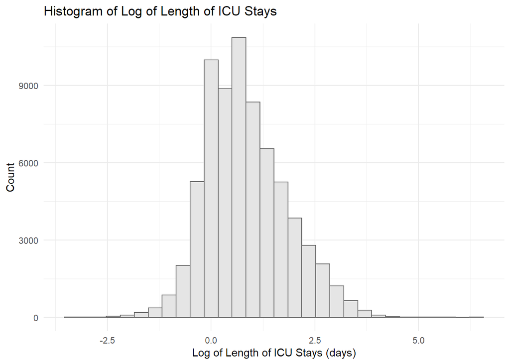

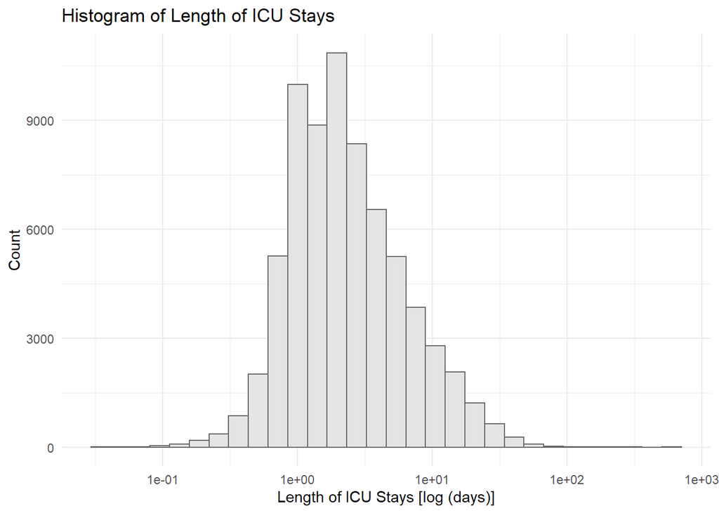

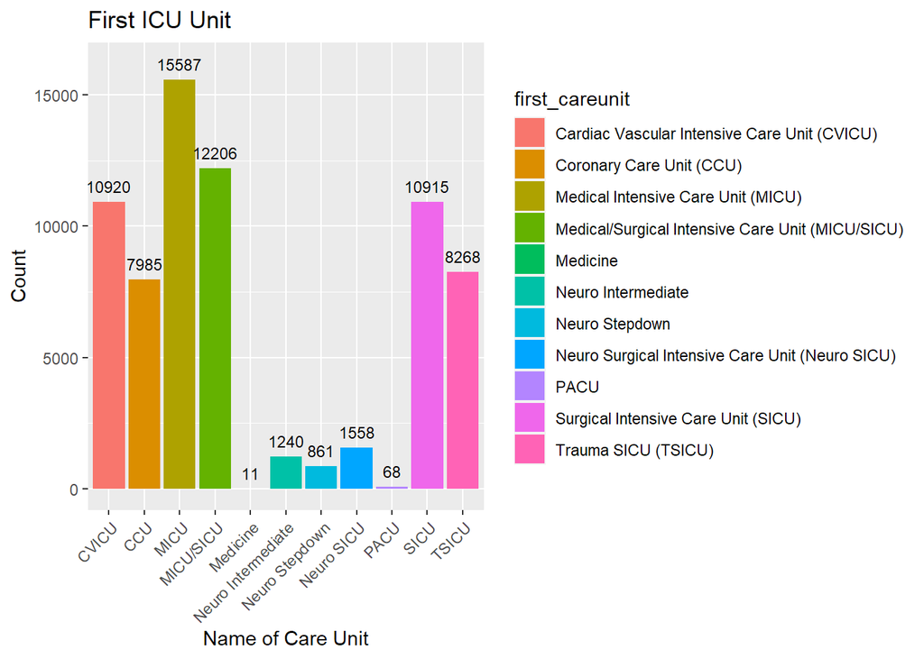

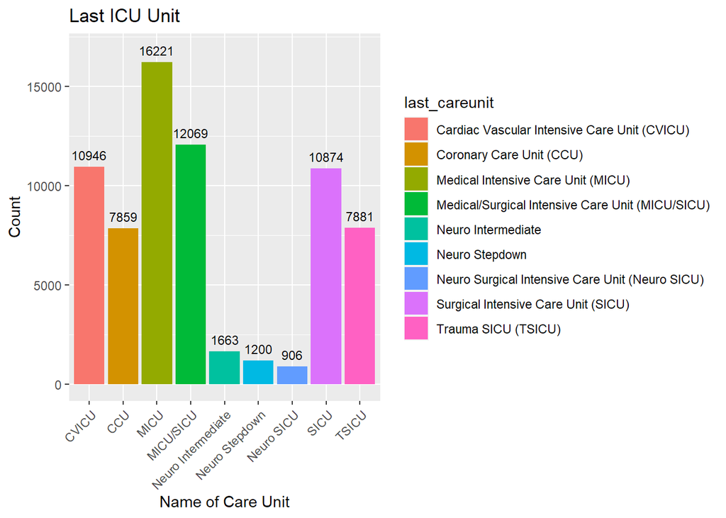

## Q4. `admission` data

Information of the patients admitted into hospital is available in `ADMISSION.csv.gz`. See https://mimic-iv.mit.edu/docs/datasets/core/admissions/ for details of each field in this file. Summarize following variables using appropriate graphs. Explain any patterns you observe.

- admission year
- admission month
- admission month day
- admission week day
- admission hour (anything unusual?)
- number of deaths in each year
- admission type
- number of admissions per patient
- admission location
- discharge location
- insurance
- language
- martial status
- ethnicity
- death

Note it is possible that one patient (uniquely identified by the `SUBJECT_ID`) is admitted into hospital multiple times. When summarizing some demographic information, it makes sense to summarize based on unique patients.

**Solution**:

Demographics (insurance, language, marital status, ethnicity) were summarized based on unique patients since these are usually consistent over time. Death was described using `hospital_expire_flag`, which is recorded per hospital stay, so only unique `subject_id` within `admission` data was used to describe death.

For admission year, there is a steep increase in admissions starting around 2115 and number of admissions stay consistently high from 2130-2185, from where it begins to drop off steeply. The distribution is slightly positively skewed.

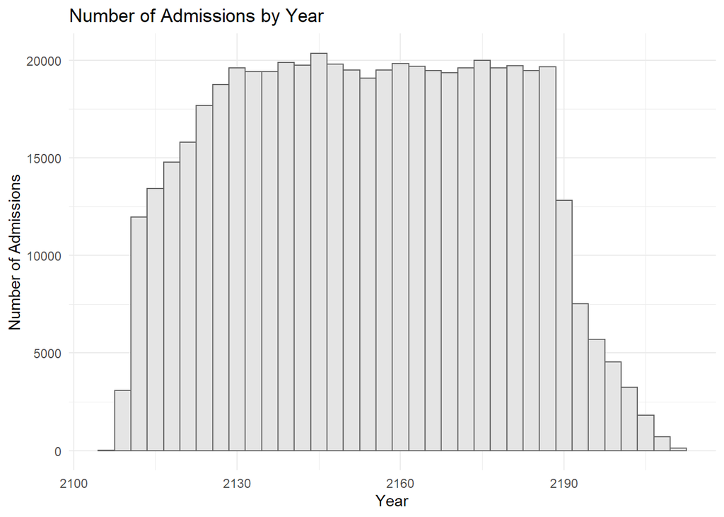

Admissions per month seem to follow the pattern of having more admissions in months that are longer (Jan, March, May, July, August, October, December all have 31 days); there is a noticeable drop in admissions for February, which has 28 (sometimes 29) days in its month. There were the highest number of admissions in August and the lowest number of admissions in February.

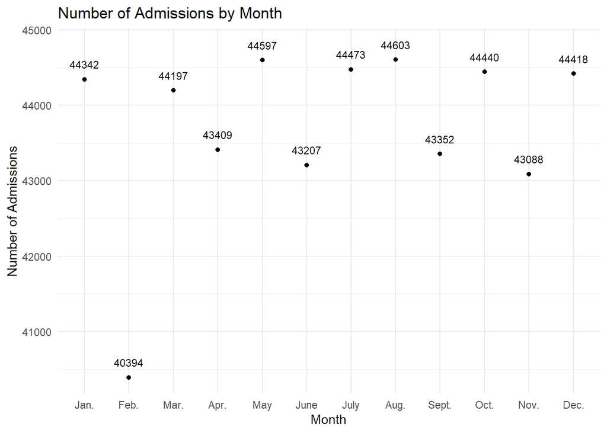

The number of admissions by day of the month is consistently high for calendar days 1-28, which makes sense since all months have at least 28 days. The numbers start dropping off as more months don’t contain that day in their respective months.

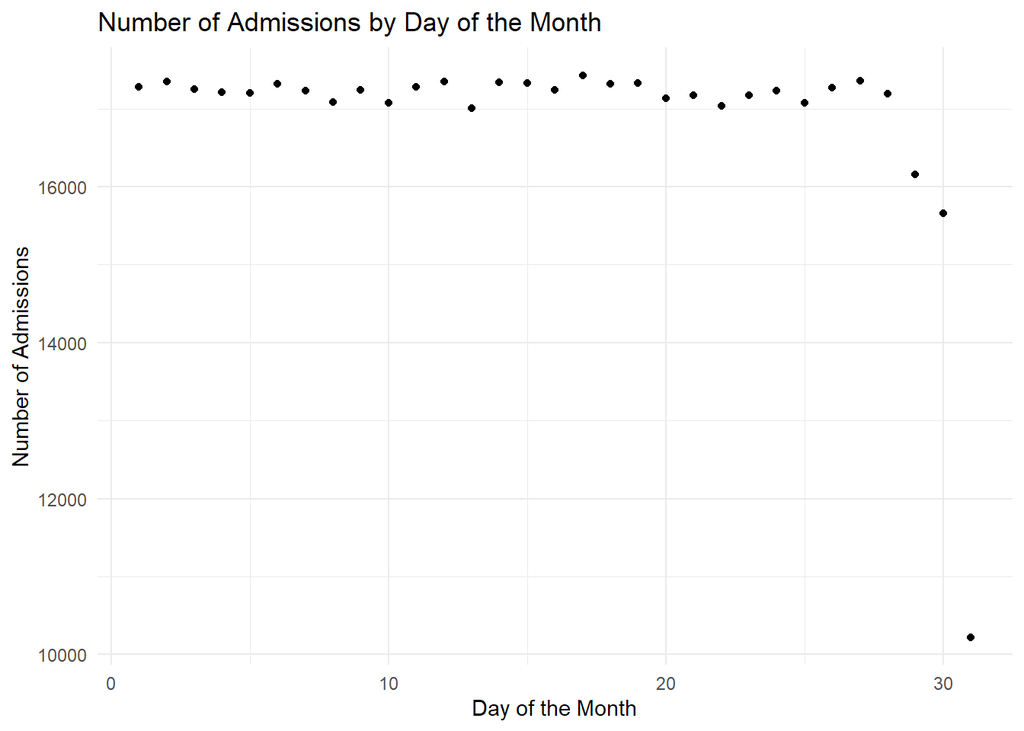

Admissions seem to be higher on the weekends, with the highest number of admissions being on Saturday and the second highest number of admissions being on Sunday. Weekdays have comparatively lower numbers of admissions.

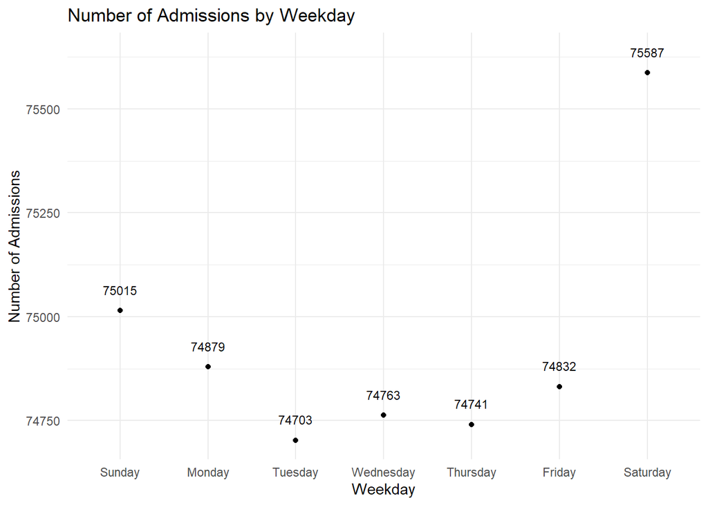

There seems to be a trend of having less admissions during the early morning hours, and admissions slowly increase from 9am and stays consistently high until the later hours of the day. There is an unusual peak at 0 hours recorded (midnight) that looks very different from the overall distribution – this could be attributed to not recording the time of admission and arbitrarily assigning a midnight admission time to some patients.

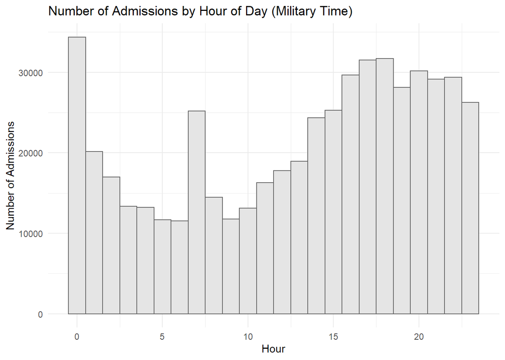

[figure not shown]

The most frequent type of admission was EW EMER. (158,032), and the least frequent type of admission was AMBULATORY OBSERVATION (7,259).

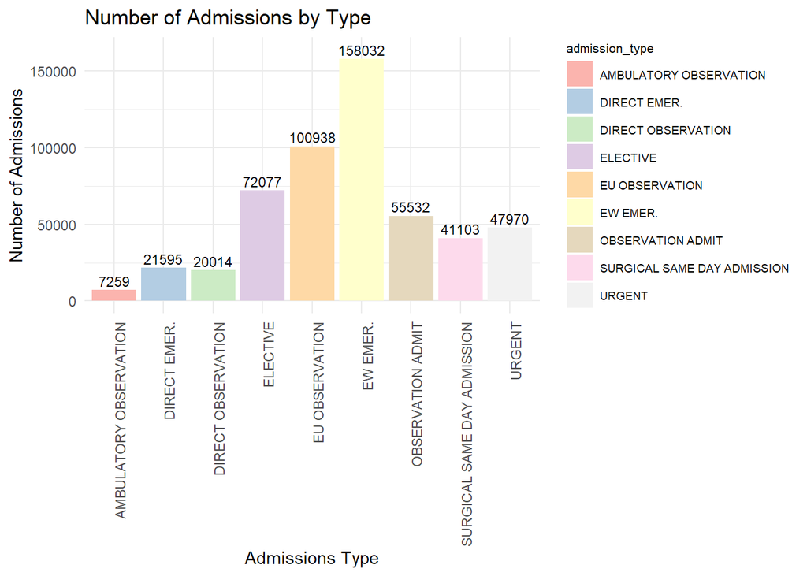

Most patients had only 1 admission, and anything past 2 admissions was considered an outlier. One patient had up to 238 admissions. The graph is extremely right skewed since most patients were in the hospital less than 2 times, as can be seen in the summary statistics produced.

```
## [1] "Summary of Number of Admissions per Patient"
```

```
##    Min. 1st Qu.  Median    Mean 3rd Qu.    Max.
##   1.000   1.000   1.000   2.038   2.000 238.000
```

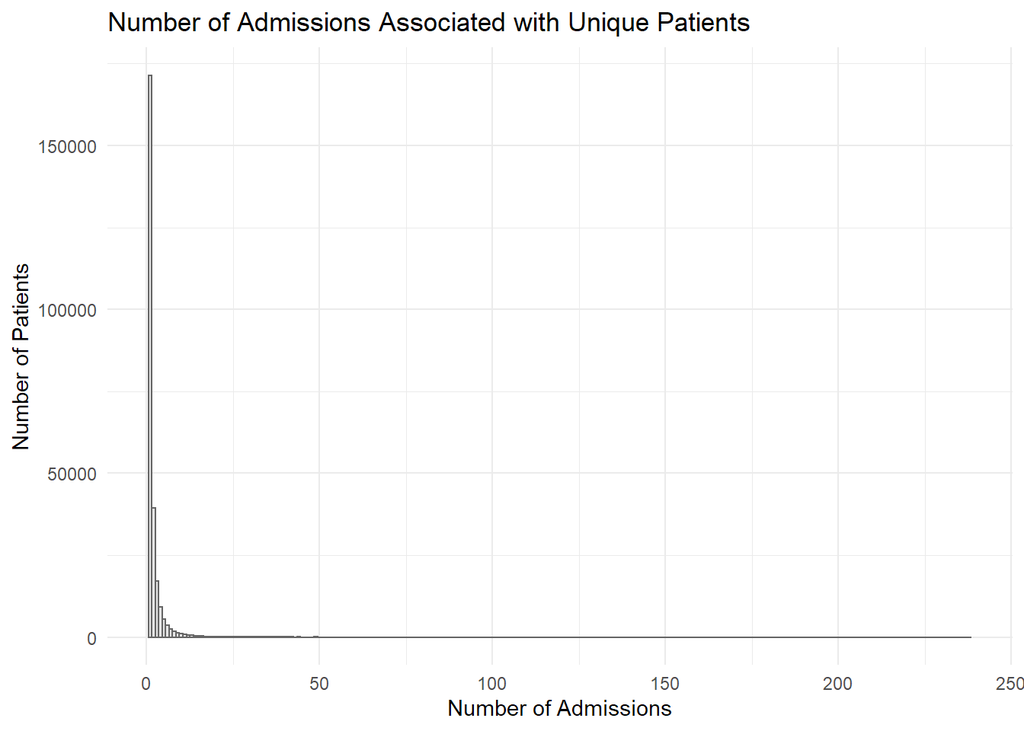

60,437 patients did not have data for their admission location. Of the patients that had data for their admission location, the most frequent admission location was the emergency room (246,241) and the least frequent was through ambulatory surgery transfer (191). Separate from the missing data for admission location, 379 patients had their admission data marked as `INFO NOT AVAILABLE`.

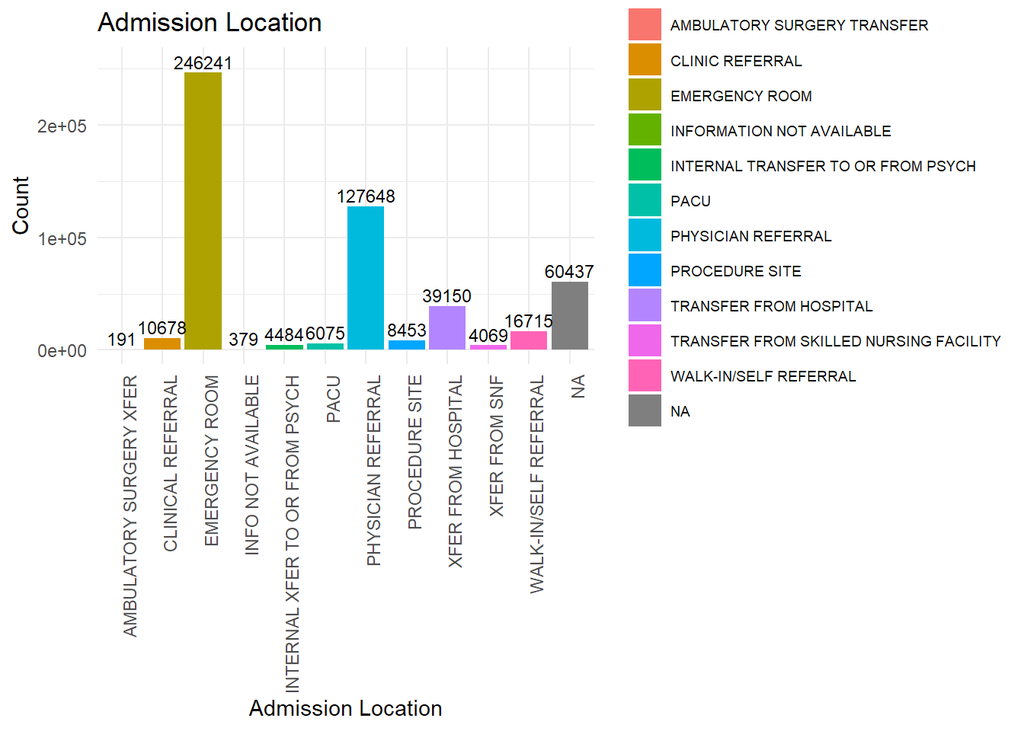

127,183 patients did not have data for their discharge location. Of the admitted patients that had discharge location data, the most common discharge location for patients was at home (222,298) and the least common discharge location for patients was at a healthcare facility. The data marks 9,257 unique patients as having died.

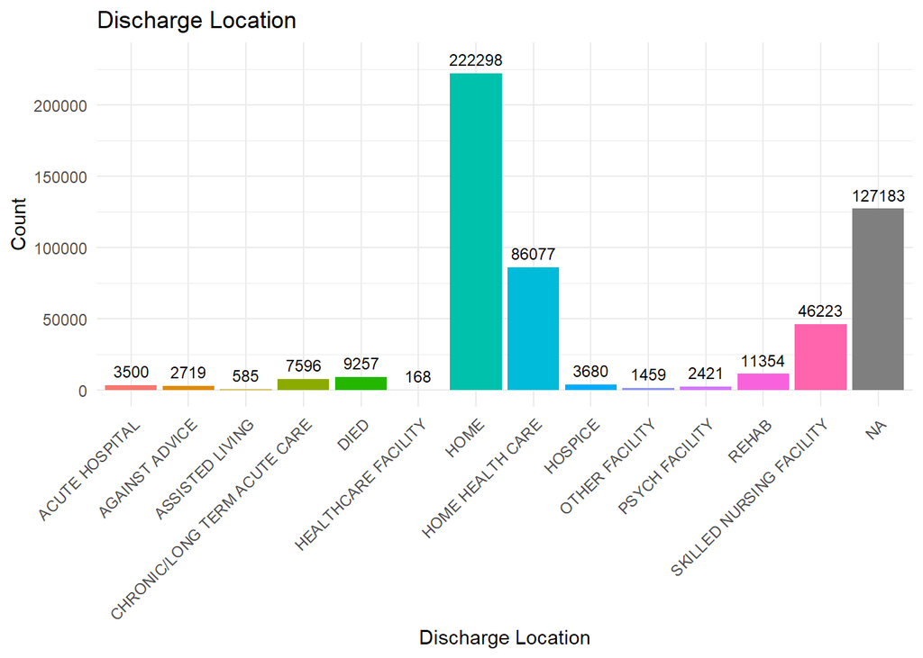

The insurance data at this hospital were coded as three different categories: `Medicaid`, `Medicare`, or `Other`. `Medicaid` was the least common insurance type (22,809), `Medicare` was the 2nd least common (60,221), and `Other` was the most common insurance type (174,336).

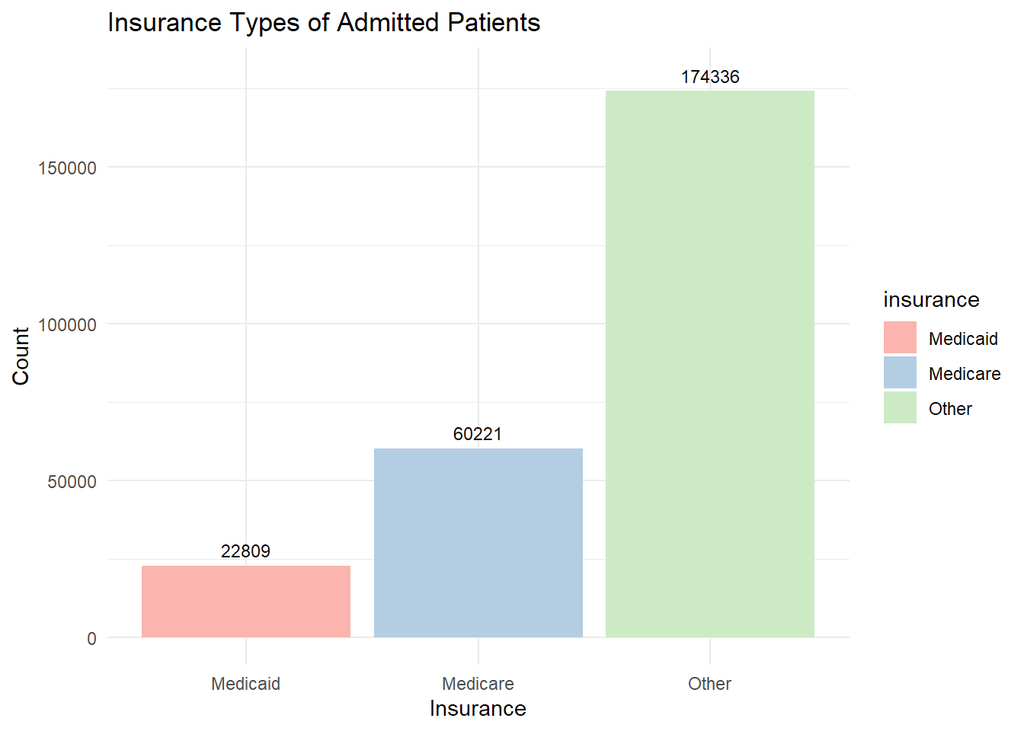

The data for language was only recorded as two values: `English` or `?`, which is not extremely informative. Of the unique admitted patients, 238,387 patients were marked as English-speaking and 18,979 were marked with `?`.

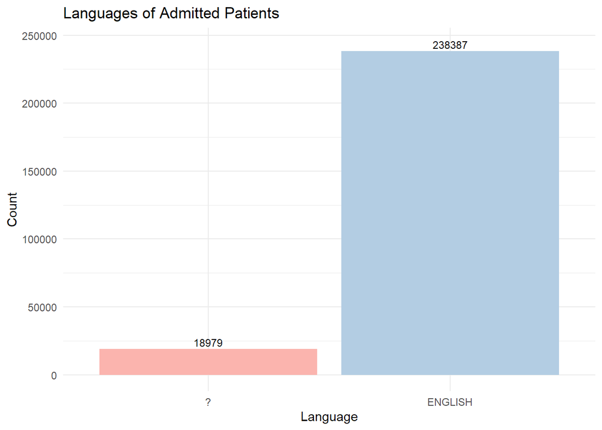

Marital status data was unavailable for 63,866 of the unique admitted patients. Of the data that were available, the majority of patients identified as either married (84,946) or single (78,458). Patients that identified as divorced were least frequent, with only 12,259 patients identifying as such.

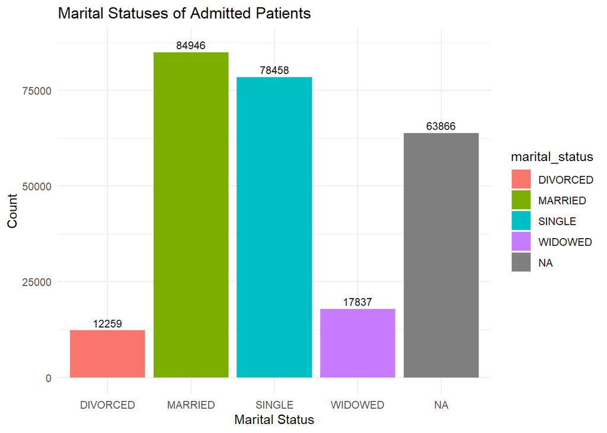

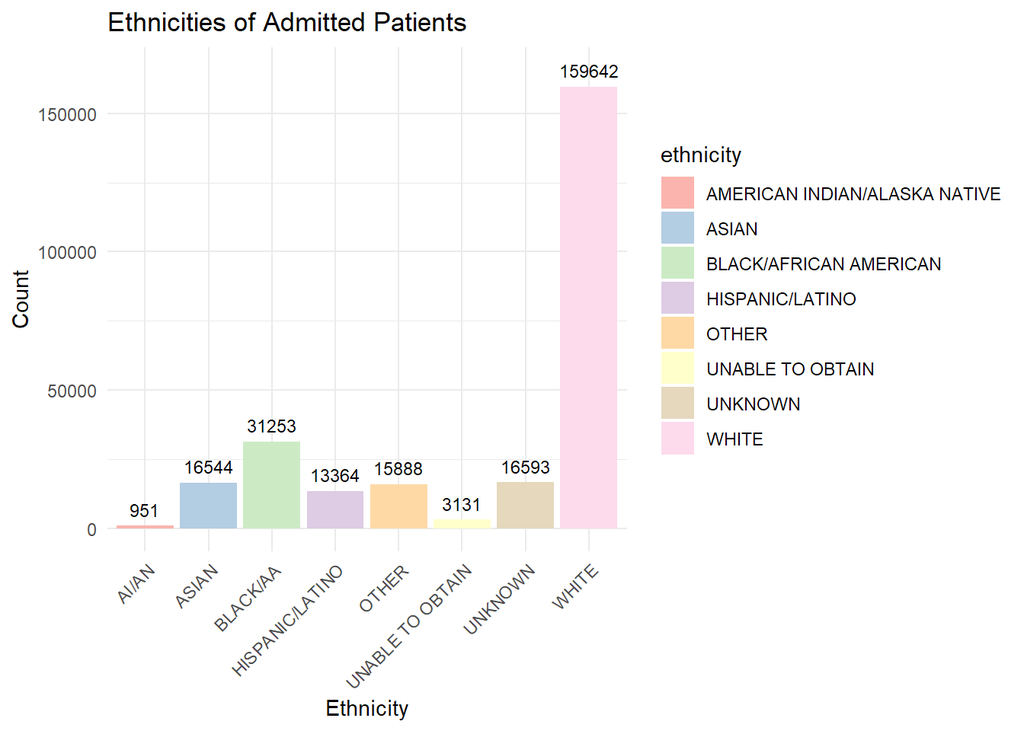

For unique patients in the admissions data, 248,004 were alive as of their last discharge time and 9,362 were deceased as of their last discharge time.

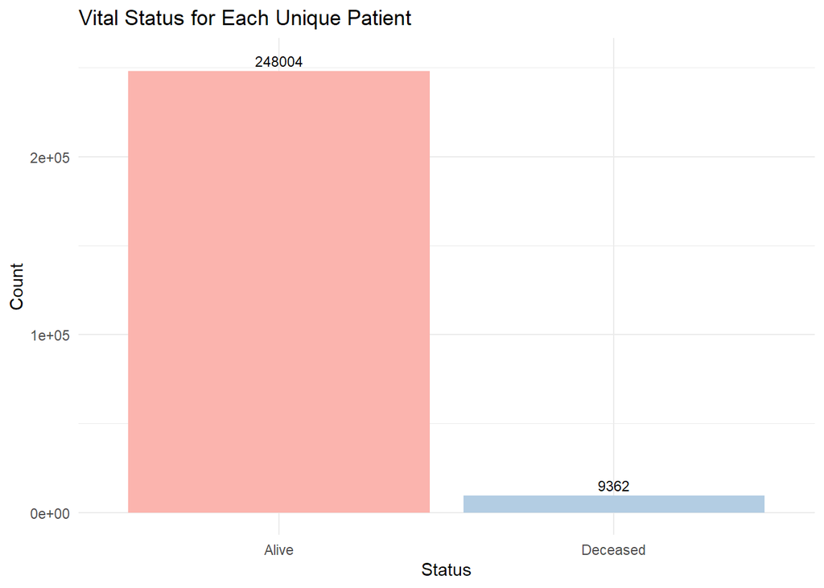

## Q5. `patient` data

Explore `patients.csv.gz` (https://mimic-iv.mit.edu/docs/datasets/core/patients/) and summarize following variables using appropriate numerics and graphs:

- `gender`
- `anchor_age` (explain pattern you see)

**Solution**:

I decided to analyze `gender` using only unique patients (unique `subject_id`) because demographic data does not change per patient. I analyzed `anchor_age` using all patients (not selecting for unique `subject_id`) because the patient’s age at admission can change per hospital/ICU admission.

More unique female patients (52.25%) were recorded than male patients (47.75%).

`anchor_age` is supposed to represent the age of the patient during the `anchor_year` listed for that same patient. However, the values of `anchor_age` seem off because there is a significant peak of over 60,000 entries where the entered `anchor_age` for a patient was equal to 0. This is a sign that there might be anomalies in data collection or unclear coding of data from the hospital system’s end (maybe the patient’s age at admission was coded 0 for unknown or underage).

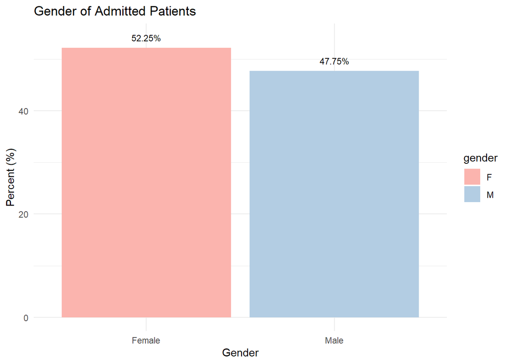

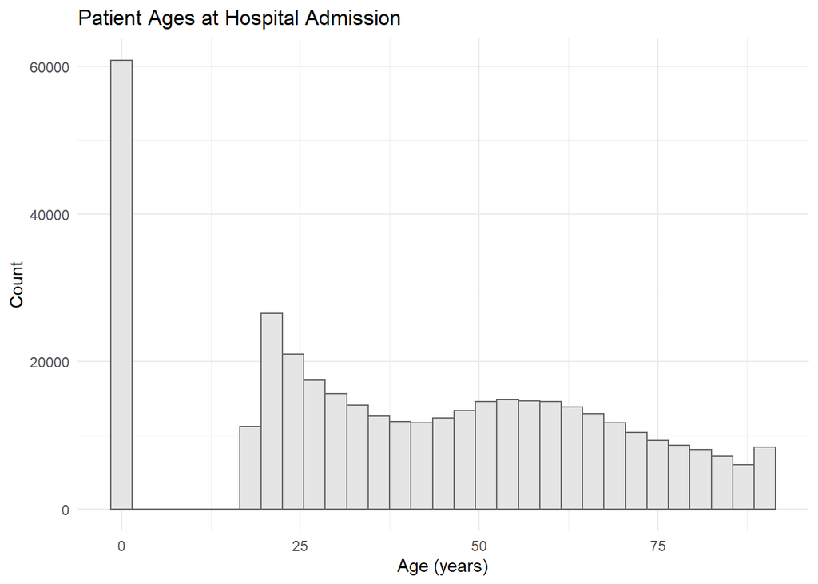

## Q6. Lab results

`labevents.csv.gz` (https://mimic-iv.mit.edu/docs/datasets/hosp/labevents/) contains all laboratory measurements for patients.

We are interested in the lab measurements of creatinine (50912), potassium (50971), sodium (50983), chloride (50902), bicarbonate (50882), hematocrit (51221), white blood cell count (51301), glucose (50931), magnesium (50960), calcium (50893), and lactate (50813). Find the `itemid`s of these lab measurements from `d_labitems.csv.gz` and retrieve a subset of `labevents.csv.gz` only containing these items.

**Solution**:

First take a look at first few lines of the `labevents.csv.gz`. `read_csv` doesn’t work (memory issues) even with reading only selected columns.

```r
system(str_c("zcat < ", shQuote(str_c(mimic_path, "/hosp/labevents.csv.gz")),
             " | head"), intern = T)
```

Reading data using data.table. Since `labevents.csv.gz` is so large, only the relevant columns are chosen in order to read in the data.

```r
if(!file.exists("labevents_icustays.csv.gz")){
 system.time(labevents <-
        fread(str_c(mimic_path, "/hosp/labevents.csv.gz"),
           select = c("subject_id", "hadm_id",
                      "itemid", "charttime", "valuenum"),
           nThread = 4))
 labevents %>%
  semi_join(icustays, by = c("subject_id", "hadm_id")) %>%
  fwrite("labevents_icustays.csv.gz", nThread = 4)
}
labevents <- fread("labevents_icustays.csv.gz")
```

```r
# LAB MEASUREMENT (ITEMID)
# creatinine (50912)
# potassium (50971)
# sodium (50983)
# chloride (50902)
# bicarbonate (50882)
# hematocrit (51221)
# white blood cell count (51301)
# glucose (50931)
# magnesium (50960)
# calcium (50893)
# lactate (50813)

v_labevents <- c(50912, 50971, 50983, 50902, 50882, 51221,
                 51301, 50931, 50960, 50893, 50813)

q6 <- labevents %>%
  filter(itemid %in% v_labevents) %>%
  #force charttime to be datetime
  mutate(charttime = ymd_hms(charttime))

head(q6, n = 10L)
```

```
##     subject_id  hadm_id itemid           charttime valuenum
##  1:   12457441 21673651  50882 2135-08-16 23:45:00     28.0
##  2:   12457441 21673651  50893 2135-08-16 23:45:00      7.5
##  3:   12457441 21673651  50902 2135-08-16 23:45:00     95.0
##  4:   12457441 21673651  50912 2135-08-16 23:45:00      0.6
##  5:   12457441 21673651  50960 2135-08-16 23:45:00      1.5
##  6:   12457441 21673651  50971 2135-08-16 23:45:00      3.0
##  7:   12457441 21673651  50983 2135-08-16 23:45:00    133.0
##  8:   12457441 21673651  51221 2135-08-16 23:45:00     14.8
##  9:   12457441 21673651  51301 2135-08-16 23:45:00      3.3
## 10:   12457441 21673651  50813 2135-08-17 00:02:00      2.0
```

## Q7. Vitals from chartered events

We are interested in the vitals for ICU patients: heart rate, mean and systolic blood pressure (invasive and noninvasive measurements combined), body temperature, SpO2, and respiratory rate.

`chartevents.csv.gz` (https://mimic-iv.mit.edu/docs/datasets/icu/chartevents/) contains all the charted data available for a patient. During their ICU stay, the primary repository of a patient’s information is their electronic chart. The `ITEMID` variable indicates a single measurement type in the database. The `VALUE` variable is the value measured for `ITEMID`.

`d_items.csv.gz` (https://mimic-iv.mit.edu/docs/datasets/icu/d_items/) is the dictionary for the `ITEMID` in `CHARTEVENTS.csv`. Find potential values of `ITEMID` that correspond to systolic blood pressure, i.e., `LABEL` contains the string `systolic`.

**Solution**:

There are over 327 million rows in `chartevents.csv.gz`. This was determined by running the following command in bash.

```bash
system(str_c("zcat < ", shQuote(str_c(mimic_path, "/icu/chartevents.csv.gz")),
             " | wc -l"), intern = T)
```

[output not shown]

```bash
# reproducible code for turning in the assignment
zcat < "/usr/203b-data/mimic-iv/icu/chartevents.csv.gz" |
  awk -F, '{if ($6 == 220045 || $6 == 220050 || $6 == 220052 ||
  $6 == 220179 || $6 == 220181 || $6 == 220210 || $6 == 223761 || $6 == 220277)
  print $1, $2, $3, $4, $6, $8} {OFS = ","}' | gzip > q7chartevents.csv.gz
```

I ran the following code locally to download and filter the dataset within Git Bash on my own WindowsOS machine:

```bash
# downloading data to my own machine:
scp -r lchen121@server.ucla-biostat-203b.com:/usr/203b-data/mimic-iv-derived-data d/

# filtering on my local machine using the shell command:
zcat < "/d/mimic-iv-0.4/mimic-iv-0.4/icu/chartevents.csv.gz" |
  awk -F, '{if ($6 == 220045 || $6 == 220050 || $6 == 220052 ||
  $6 == 220179 || $6 == 220181 || $6 == 220210 || $6 == 223761 || $6 == 220277)
  print $1, $2, $3, $4, $6, $8} {OFS = ","}' | gzip > q7chartevents.csv.gz

# transferring my filtered chart events back to the teaching server
# scp filename username@server.ucla-biostat-203b.com:fullpathtohwfolder
scp q7chartevents.csv.gz lchen121@server.ucla-biostat-203b.com:
/home/lchen121/biostat-203b-2021-winter/hw2/
```

```r
if(!file.exists("chartevents_icustays.csv.gz")){
 system.time(chartevents <-
        fread(str_c(mimic_path, "/icu/q7chartevents.csv.gz"),
           nThread = 4))
 names(chartevents) <- c("subject_id", "hadm_id", "stay_id",
                         "charttime", "itemid", "valuenum")
 chartevents %>%
  semi_join(icustays, by = c("subject_id", "hadm_id", "stay_id")) %>%
  fwrite("chartevents_icustays.csv.gz", nThread = 4)
}
chartevents <- fread("chartevents_icustays.csv.gz")
```

I ran a chunk of 2000 lines to see if I could find all the requested vitals within this initial chunk. Looking through the item dictionary for `chartevents.csv.gz`, 8 different itemids were identified as the requested vitals to keep from this dataset.

```r
# transactFile <- str_c(mimic_path,"/icu/d_items.csv.gz")
# chunkSize <- 2000
# con <- file(description= transactFile, open="r")
# data <- read.table(con, nrows=chunkSize, header=T, fill=TRUE, sep=",")
# close(con)

# CHART EVENT (ITEMID LABEL)
# heart rate (220045 Heart Rate)

# mean bp (invasive and noninvasive measurements combined)
# (220052 Arterial Blood Pressure mean)
# (220181 Non Invasive Blood Pressure mean)

# systolic bp (invasive and noninvasive measurements combined)
# (220050 Arterial Blood Pressure systolic)
# (220179 Non Invasive Blood Pressure systolic)

# body temperature (choose only one since we are doing linear regression)
# (223761 Temperature Fahrenheit)

# SpO2 [(229862 Forehead SpO2 Sensor In Place) - what Dr. Zhou used]
# (220277 O2 saturation pulseoxymetry) - what I used

# respiratory rate
# (220210 Respiratory Rate)

v_chartevents <- c(220045, 220052, 220181, 220050,
                   220179, 223761, 229862, 220210)

# chartevents already has the itemids listed in v_chartevents, so the vector
# will not be used

q7 <- chartevents %>%
  as_tibble() %>%
  #force charttime to be datetime
  mutate(charttime = ymd_hms(charttime))

head(q7, n= 10L)
```

```
## # A tibble: 10 x 6
##    subject_id  hadm_id  stay_id charttime           itemid valuenum
##         <int>    <int>    <int> <dttm>               <int>    <dbl>
##  1   10003700 28623837 35053963 2165-04-24 05:28:00 220179    152
##  2   10003700 28623837 35053963 2165-04-24 05:28:00 220181    110
##  3   10003700 28623837 35053963 2165-04-24 05:30:00 220045     65
##  4   10003700 28623837 35053963 2165-04-24 05:30:00 220210     14
##  5   10003700 28623837 35053963 2165-04-24 05:31:00 220277    100
##  6   10003700 28623837 35053963 2165-04-24 05:38:00 223761     97.6
##  7   10003700 28623837 35053963 2165-04-24 06:00:00 220045     56
##  8   10003700 28623837 35053963 2165-04-24 06:00:00 220179    126
##  9   10003700 28623837 35053963 2165-04-24 06:00:00 220181     88
## 10   10003700 28623837 35053963 2165-04-24 06:00:00 220210     14
```

## Q8. Putting things together

Let us create a tibble for all ICU stays, where rows are

- first ICU stay of each unique patient
- adults (age at admission > 18)

and columns contains at least following variables

- all variables in `icustays.csv.gz`
- all variables in `admission.csv.gz`
- all variables in `patients.csv.gz`
- first lab measurements during ICU stay
- first vitals measurement during ICU stay
- an indicator variable whether the patient died within 30 days of hospital admission #30 day mortality Y/N variable

**Solution**:

First, remove excess variables from the global environment to ease memory:

```r
rm(list = ls(pattern = "q5"))
rm(list = ls(pattern = "q4"))
rm(list = ls(pattern = "values"))
rm(list = ls(pattern = "count"))
```

```r
icustays_unique <- icustays %>%
  group_by(subject_id) %>%
  slice_min(intime) %>%
  # merge admissions data
  left_join(admissions, by = c("subject_id", "hadm_id")) %>%
  # merge patients data
  left_join(patients, by = "subject_id") %>%
  mutate(admitage = year(admittime) - anchor_year + anchor_age) %>%
  filter(admitage >= 18)

head(icustays_unique, n = 10L)
```

```
## # A tibble: 10 x 27
## # Groups:   subject_id [10]
##    subject_id hadm_id stay_id first_careunit last_careunit intime outtime   los
##         <dbl>   <int>   <int> <chr>          <chr>         <chr>  <chr>   <dbl>
##  1   10000032  2.91e7  3.75e7 Medical Inten~ Medical Inte~ 2180-~ 2180-0~ 0.410
##  2   10000980  2.69e7  3.67e7 Medical Inten~ Medical Inte~ 2189-~ 2189-0~ 0.498
##  3   10001217  2.46e7  3.03e7 Surgical Inte~ Surgical Int~ 2157-~ 2157-1~ 1.12
##  4   10001725  2.56e7  3.75e7 Medical/Surgi~ Medical/Surg~ 2110-~ 2110-0~ 1.34
##  5   10001884  2.62e7  3.18e7 Medical Inten~ Medical Inte~ 2131-~ 2131-0~ 9.17
##  6   10002013  2.36e7  3.71e7 Cardiac Vascu~ Cardiac Vasc~ 2160-~ 2160-0~ 1.31
##  7   10002155  2.38e7  3.46e7 Coronary Care~ Coronary Car~ 2129-~ 2129-0~ 6.18
##  8   10002223  2.25e7  3.99e7 Trauma SICU (~ Trauma SICU ~ 2158-~ 2158-0~ 1.30
##  9   10002428  2.87e7  3.20e7 Medical Inten~ Medical Inte~ 2156-~ 2156-0~ 7.08
## 10   10002443  2.13e7  3.52e7 Coronary Care~ Coronary Car~ 2183-~ 2183-1~ 2.75
## # ... with 19 more variables: admittime <chr>, dischtime <chr>,
## #   deathtime <chr>, admission_type <chr>, admission_location <chr>,
## #   discharge_location <chr>, insurance <chr>, language <chr>,
## #   marital_status <chr>, ethnicity <chr>, edregtime <chr>, edouttime <chr>,
## #   hospital_expire_flag <int>, gender <chr>, anchor_age <dbl>,
## #   anchor_year <dbl>, anchor_year_group <chr>, dod <lgl>, admitage <dbl>
```

```r
q8labs <- q6 %>%
  # only keep subject_id+hadm_id that are in icustays_unique
  semi_join(icustays_unique, by = c("subject_id", "hadm_id")) %>%
 # pull in the intime of the specific icu stay
 left_join(select(icustays_unique, subject_id, hadm_id, intime),
           by = c("subject_id", "hadm_id")) %>%
  # only keep lab items after ICU intime
  filter(charttime >= intime) %>%
  # group by itemid
  group_by(subject_id, itemid) %>%
  # only keep first charttime for each item in each subject_id
  arrange(charttime, .by_group = T) %>%
  slice_head(n = 1) %>%
  # remove charttime and intime
  select(-charttime, -intime) %>%
  spread(key = itemid, value = valuenum)
head(q8labs, n = 10L)
```

```
## # A tibble: 10 x 13
## # Groups:   subject_id [10]
##    subject_id hadm_id `50813` `50882` `50893` `50902` `50912` `50931` `50960`
##         <dbl>   <int>   <dbl>   <dbl>   <dbl>   <dbl>   <dbl>   <dbl>   <dbl>
##  1   10000032  2.91e7    NA        21     9.3     102     0.5     115     2.3
##  2   10000980  2.69e7    NA        23     9.2     103     2.2     144     2
##  3   10001217  2.46e7    NA        22     7.9     108     0.7     112     2.1
##  4   10001725  2.56e7    NA        24     9.1     106     0.8     146     1.5
##  5   10001884  2.62e7     1.1      33     8.7      98     1       145     2.2
##  6   10002013  2.36e7     2.3      23    NA       109     1.1      98     2.1
##  7   10002155  2.38e7    NA        25     8.8     106     0.9      95     2
##  8   10002223  2.25e7    NA        26     8.7     102     0.8      88     2
##  9   10002428  2.87e7     1.6      20     7.4      98     0.8      99     1.4
## 10   10002443  2.13e7     1.9      20     7.6     103     0.8     189     2.4
## # ... with 4 more variables: `50971` <dbl>, `50983` <dbl>, `51221` <dbl>,
## #   `51301` <dbl>
```

```r
# subsetting q7 to only have a chunk of 10million lines since I can't knit
# the homework with the full data set
q7 <- q7 %>%
  slice(1:100000)

q8vitals <- q7 %>%
  # only keep subject_id+hadm_id+stay_id from icustays_unique
  semi_join(icustays_unique, by = c("subject_id", "hadm_id", "stay_id")) %>%
  # pull in the intime of the specific icu stay
  left_join(select(icustays_unique, subject_id, hadm_id, intime),
            by = c("subject_id", "hadm_id")) %>%
  # only keep lab items after ICU intime
  filter(charttime >= intime) %>%
  # group by itemid
  group_by(subject_id, itemid) %>%
  # only keep first charttime for each item in each subject_id
  arrange(charttime, .by_group = T) %>%
  slice_head(n = 1) %>%
  # remove charttime and intime
  select(-charttime, -intime) %>%
  spread(key = itemid, value = valuenum) %>%
  # there are some duplicate measurements for some reason even though we sliced
  distinct(subject_id, .keep_all = T)

head(q8vitals, n = 10L)
```

```
## # A tibble: 10 x 11
## # Groups:   subject_id [10]
##    subject_id hadm_id stay_id `220045` `220050` `220052` `220179` `220181`
##         <dbl>   <int>   <int>    <dbl>    <dbl>    <dbl>    <dbl>    <dbl>
##  1   10004235  2.42e7  3.03e7      110       97       73       99       74
##  2   10004720  2.21e7  3.03e7       75       NA       NA      106       73
##  3   10005348  2.52e7  3.15e7       80      103       66      109       67
##  4   10006580  2.42e7  3.75e7       83      164      101       NA       NA
##  5   10007677  2.72e7  3.22e7       64       NA       NA      108       75
##  6   10009035  2.83e7  3.30e7      112      117       74      100       69
##  7   10017851  2.34e7  3.31e7      106       NA       NA      108       73
##  8   10018928  2.25e7  3.98e7       91       NA       NA      122       86
##  9   10019003  2.93e7  3.10e7      104       NA       NA      121       73
## 10   10019992  2.94e7  3.43e7       57       NA       NA       98       72
## # ... with 3 more variables: `220210` <dbl>, `220277` <dbl>, `223761` <dbl>
```

```r
#joining all subsets and renaming columns

q8oldnames <- c(names(q8vitals), names(q8labs)[-(1:2)],
            "dischtime", "admittime", "hospital_expire_flag", "binary_death30")

q8names <- c("subject_id", "hadm_id", "stay_id", "Heart Rate (bpm)",
             "Arterial Blood Pressure systolic (mmHg)",
             "Arterial Blood Pressure mean (mmHg)",
             "Non Invasive Blood Pressure systolic (mmHg)",
             "Non Invasive Blood Pressure mean (mmHg)",
             "Respiratory Rate (insp/min)",
             "O2 saturation pulseoxymetry (%)",
             "Temperature Fahrenheit (F)",
             "Lactate", "Bicarbonate", "Calcium",
             "Chloride", "Creatinine", "Glucose",
             "Magnesium", "Potassium", "Sodium",
             "Hematocrit", "White Blood Cell Count",
             "dischtime", "admittime", "hospital_expire_flag", "binary_death30")


q8full <- q8vitals %>%
  # join labevents data
  left_join(q8labs, by = c("subject_id", "hadm_id")) %>%
  # add in all of the unique data from admissions/icustays/patients
  left_join(select(icustays_unique, dischtime, subject_id, hadm_id, stay_id,
                   admittime, hospital_expire_flag),
            by = c("subject_id", "hadm_id", "stay_id")) %>%
  # create indicator variable whether pt died within 30 days of admittime
  # deathtime missing for some hospital_expire_flag = 1, use dischtime instead
  mutate(binary_death30 = if_else((hospital_expire_flag == 1
                      & (difftime(dischtime, admittime, units="days") > 0)
                      & (difftime(dischtime, admittime, units="days") < 30))
                      , 1, 0)) %>%
  # rename columns to descriptive names
  rename_at(vars(as.character(q8oldnames)), ~q8names)

head(q8full, n= 20L)
```

```
## # A tibble: 20 x 26
## # Groups:   subject_id [20]
##    subject_id hadm_id stay_id `Heart Rate (bp~ `Arterial Blood~ `Arterial Blood~
##         <dbl>   <int>   <int>            <dbl>            <dbl>            <dbl>
##  1   10004235  2.42e7  3.03e7              110               97               73
##  2   10004720  2.21e7  3.03e7               75               NA               NA
##  3   10005348  2.52e7  3.15e7               80              103               66
##  4   10006580  2.42e7  3.75e7               83              164              101
##  5   10007677  2.72e7  3.22e7               64               NA               NA
##  6   10009035  2.83e7  3.30e7              112              117               74
##  7   10017851  2.34e7  3.31e7              106               NA               NA
##  8   10018928  2.25e7  3.98e7               91               NA               NA
##  9   10019003  2.93e7  3.10e7              104               NA               NA
## 10   10019992  2.94e7  3.43e7               57               NA               NA
## 11   10020852  2.35e7  3.77e7               69               NA               NA
## 12   10021312  2.88e7  3.74e7               90               NA               NA
## 13   10022584  2.46e7  3.01e7               75               NA               NA
## 14   10023708  2.15e7  3.82e7               81               NA               NA
## 15   10026161  2.46e7  3.97e7               74               92               73
## 16   10029224  2.57e7  3.59e7               76               NA               NA
## 17   10030163  2.36e7  3.55e7               80               NA               NA
## 18   10031358  2.95e7  3.38e7               65               NA               NA
## 19   10035168  2.54e7  3.20e7               89              118               92
## 20   10035631  2.93e7  3.53e7              123               84               60
## # ... with 20 more variables: `Non Invasive Blood Pressure systolic
## #   (mmHg)` <dbl>, `Non Invasive Blood Pressure mean (mmHg)` <dbl>,
## #   `Respiratory Rate (insp/min)` <dbl>, `O2 saturation pulseoxymetry
## #   (%)` <dbl>, `Temperature Fahrenheit (F)` <dbl>, Lactate <dbl>,
## #   Bicarbonate <dbl>, Calcium <dbl>, Chloride <dbl>, Creatinine <dbl>,
## #   Glucose <dbl>, Magnesium <dbl>, Potassium <dbl>, Sodium <dbl>,
## #   Hematocrit <dbl>, `White Blood Cell Count` <dbl>, dischtime <chr>,
## #   admittime <chr>, hospital_expire_flag <int>, binary_death30 <dbl>
```